# tidydice

Roland Krasser

2023-02-03

### Introduction

A basic understanding of probability and statistics is crucial for data understanding and discovery of meaningful patterns. A great way to teach probability and statistics is to start with an experiment, like rolling a dice or flipping a coin.

This package simulates rolling a dice and flipping a coin. Each experiment generates a tibble. Dice rolls and coin flips are simulated using sample(). The properties of the dice can be changed, like the number of sides. A coin flip is simulated using a two sided dice. Experiments can be combined with the pipe-operator.

tidydice package on Github: https://github.com/rolkra/tidydice

### Setup

As the tidydice-functions fits well into the tidyverse, we load the dplyr-package. For quick visualisations we use the explore-package. To create more flexible graphics, use ggplot2.

```r
library(tidydice)
library(dplyr)
library(explore)
```

### Roll a dice

#### Example

6 dice are rolled 3 times using roll_dice(). The result of the dice-experiment is visualised using plot_dice().

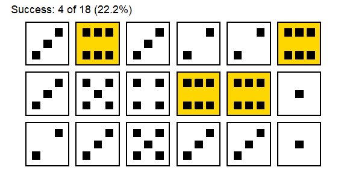

```r
set.seed(123)
roll_dice(times = 6, rounds = 3) %>%
  plot_dice()
```

#### Roll a dice once

The output of roll_dice() is a tibble. Each row represents a dice roll. Without parameters, a dice is rolled once. You can use plot_dice() to visualise the result.

```r
set.seed(123)
roll_dice()
```

```
#> # A tibble: 1 x 5
#>   experiment round    nr result success
#>        <int> <int> <int>  <int> <lgl>
#> 1          1     1     1      3 FALSE
```

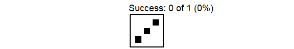

```r
set.seed(123)
roll_dice() %>% plot_dice()
```

#### Define success

```r
set.seed(123)
roll_dice(success = c(2,6))
```

```
#> # A tibble: 1 x 5
#>   experiment round    nr result success
#>        <int> <int> <int>  <int> <lgl>
#> 1          1     1     1      3 FALSE
```

#### Unfair dice

```r
set.seed(123)
roll_dice(prob = c(0,0,0,0,0,1))
```

```
#> # A tibble: 1 x 5
#>   experiment round    nr result success
#>        <int> <int> <int>  <int> <lgl>
#> 1          1     1     1      6 TRUE
```

In this case we created a dice that always gets result = 6 (with 100% probability)

#### Untypically dice

As default the dice has 6 sides. If you want you can change this. Here we use a dice with 12 sides. result now can have a value between 1 and 12. But result = 6 is still the default success.

```r
set.seed(123)
roll_dice(sides = 12)
```

```
#> # A tibble: 1 x 5
#>   experiment round    nr result success
#>        <int> <int> <int>  <int> <lgl>
#> 1          1     1     1      3 FALSE
```

#### Roll a dice 4 times

```r
set.seed(123)
roll_dice(times = 4)
```

```
#> # A tibble: 4 x 5
#>   experiment round    nr result success
#>        <int> <int> <int>  <int> <lgl>
#> 1          1     1     1      3 FALSE
#> 2          1     1     2      6 TRUE
#> 3          1     1     3      3 FALSE
#> 4          1     1     4      2 FALSE
```

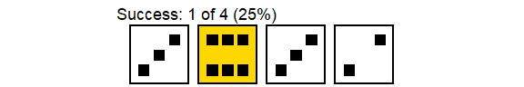

```r
set.seed(123)
roll_dice(times = 4) %>% plot_dice()
```

We get 1 success

#### Define rounds

```r
set.seed(123)
roll_dice(times = 4, rounds = 2)
```

```
#> # A tibble: 8 x 5
#>   experiment round    nr result success
#>        <int> <int> <int>  <int> <lgl>
#> 1          1     1     1      3 FALSE
#> 2          1     1     2      6 TRUE
#> 3          1     1     3      3 FALSE
#> 4          1     1     4      2 FALSE
#> 5          1     2     1      2 FALSE
#> 6          1     2     2      6 TRUE
#> 7          1     2     3      3 FALSE
#> 8          1     2     4      5 FALSE
```

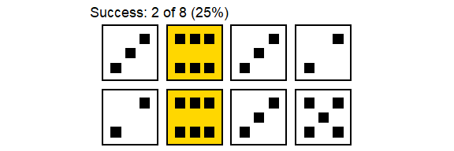

```r
set.seed(123)
roll_dice(times = 4, rounds = 2) %>% plot_dice()
```

#### Use agg

A convenient way to aggregate the result, is to use the agg parameter. Now we get one line per round.

```r
set.seed(123)
roll_dice(times = 4, rounds = 2, agg = TRUE)
```

```
#> # A tibble: 2 x 4
#>   experiment round times success
#>        <int> <int> <int>   <int>
#> 1          1     1     4       1
#> 2          1     2     4       1
```

You can aggregate by hand too using dplyr.

```r
set.seed(123)
roll_dice(times = 4, rounds = 2) %>%
  group_by(experiment, round) %>%
  summarise(times = n(),
            success = sum(success))
```

```
#> # A tibble: 2 x 4
#> # Groups:   experiment [1]
#>   experiment round times success
#>        <int> <int> <int>   <int>
#> 1          1     1     4       1
#> 2          1     2     4       1
```

#### Visualise result

You can use any package/tool you like to visualise the result. In this example we use the explore-package.

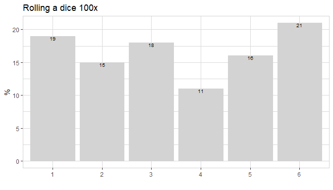

```r
set.seed(123)
roll_dice(times = 100) %>%
  explore(result, title = "Rolling a dice 100x")
```

If we increase the times parameter to 10000, the results are more balanced.

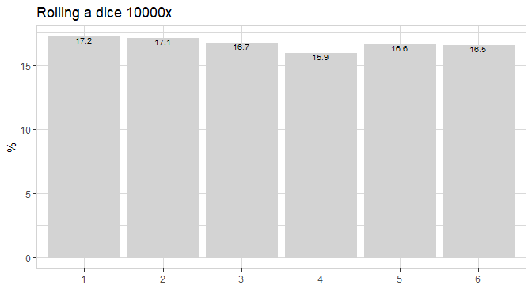

```r
set.seed(123)
roll_dice(times = 10000) %>%
  explore(result, title = "Rolling a dice 10000x")
```

#### Visualise success

If we repeat the experiment rolling a dice 100x with rounds = 100, we get the distribution with a peak at about 17 (16.67 is the expected value)

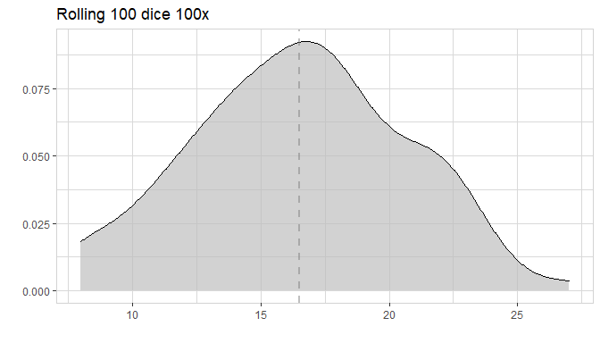

```r
set.seed(123)
roll_dice(times = 100, rounds = 100, agg = TRUE) %>%
  explore(success,
          title = "Rolling 100 dice 100x",
          auto_scale = FALSE)
```

If we increase rounds from 100 to 10000 we get a more symmetric shape. We see that success below 5 and success above 30 are very unlikely.

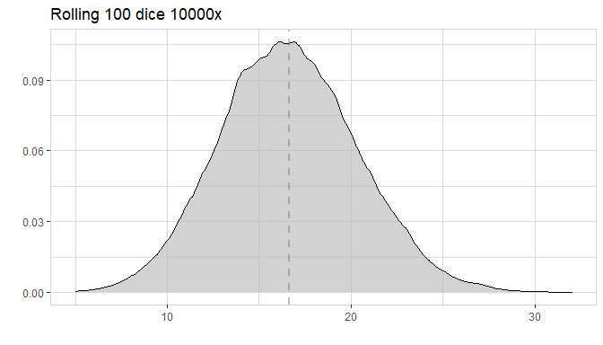

```r
set.seed(123)
roll_dice(times = 100, rounds = 10000, agg = TRUE) %>%
  explore(success,
          title = "Rolling 100 dice 10000x",
          auto_scale = FALSE)
```

This shape is already very close to the binomial distribution

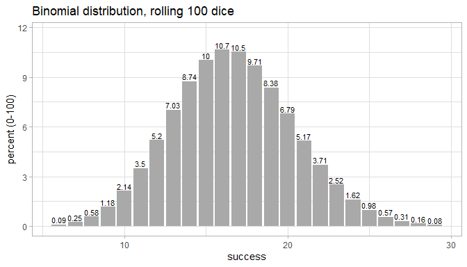

```r
binom_dice(times = 100) %>%
  plot_binom(title = "Binomial distribution, rolling 100 dice")
```

```r
set.seed(123)
roll_dice(times = 100, rounds = 10000, agg = TRUE) %>%
  mutate(check = ifelse(success < 5 | success > 30, 1, 0)) %>%
  count(check)
```

```
#> # A tibble: 2 x 2
#>   check     n
#>   <dbl> <int>
#> 1     0  9998
#> 2     1     2
```

We can check that with the binomial distribution too:

```r
binom_dice(times = 100) %>%
  filter(success < 5 | success > 30)
```

```
#> # A tibble: 75 x 3
#>    success            p        pct
#>      <int>        <dbl>      <dbl>
#>  1       0 0.0000000121 0.00000121
#>  2       1 0.000000241  0.0000241
#>  3       2 0.00000239   0.000239
#>  4       3 0.0000156    0.00156
#>  5       4 0.0000758    0.00758
#>  6      31 0.000172     0.0172
#>  7      32 0.0000742    0.00742
#>  8      33 0.0000306    0.00306
#>  9      34 0.0000120    0.00120
#> 10      35 0.00000454   0.000454
#> # ... with 65 more rows
```

```r
binom_dice(times = 100) %>%
  filter(success < 5 | success > 30) %>%
  summarise(check_pct = sum(pct))
```

```
#> # A tibble: 1 x 1
#>   check_pct
#>       <dbl>
#> 1    0.0390
```

The probability to get this result is 0.04% (based on the binomial distribution).

#### Combine experiments

Let’s add an experiment, where you have 10 extra dice. The shape of the distribution changes.

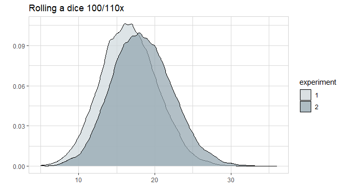

```r
set.seed(123)
roll_dice(times = 100, rounds = 10000, agg = TRUE) %>%
  roll_dice(times = 110, rounds = 10000, agg = TRUE) %>%
  explore(success,
          target = experiment,
          title = "Rolling a dice 100/110x",
          auto_scale = FALSE)
```

You can add as many experiments as you like (as long they generate the same data structure)

Adding an experiment with times = 150 will generate a smaller but wider shape.

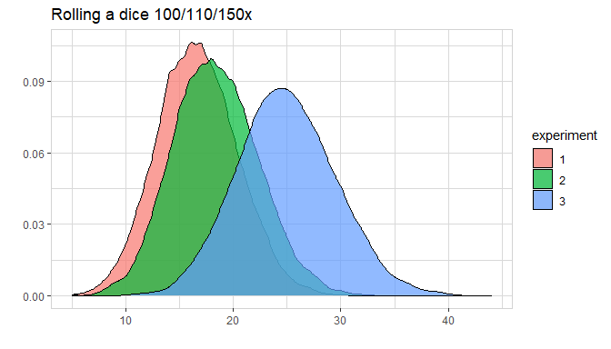

```r
set.seed(123)
roll_dice(times = 100, rounds = 10000, agg = TRUE) %>%
  roll_dice(times = 110, rounds = 10000, agg = TRUE) %>%
  roll_dice(times = 150, rounds = 10000, agg = TRUE) %>%
  explore(success,
          target = experiment,
          title = "Rolling a dice 100/110/150x",
          auto_scale = FALSE)
```

#### Binomial distribution

Rolling a dice 100x, a result between 10 and 23 has a probability of over 94%

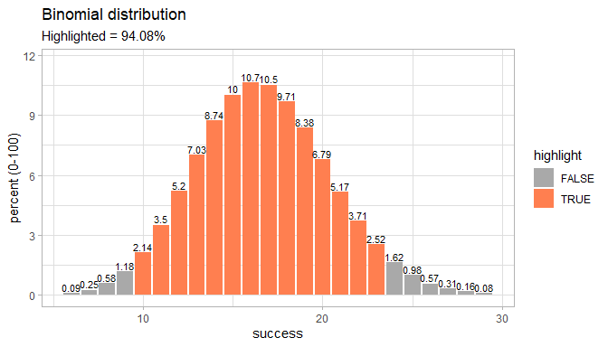

```r
binom_dice(times = 100) %>%
  plot_binom(highlight = c(10:23))
```

### Flip a coin

Internally the package handles coins as dice with only two sides. Success is defined as result = 2 (as default), while result = 1 is not a success.

#### Flip a coin 10x

```r
set.seed(123)
flip_coin(times = 10)
```

[output not shown]

```r
set.seed(123)
flip_coin(times = 10) %>%
  describe(success)
```

[output not shown]

Or just use the agg-parameter

```r
set.seed(123)
flip_coin(times = 10, agg = TRUE)
```

```
#> # A tibble: 1 x 4
#>   experiment round times success
#>        <int> <int> <int>   <int>
#> 1          1     1    10       4
```

#### Define rounds

The parameter rounds can be used like in roll_dice().

```r
set.seed(123)
flip_coin(times = 10, rounds = 4, agg = TRUE)
```

```
#> # A tibble: 4 x 4
#>   experiment round times success
#>        <int> <int> <int>   <int>
#> 1          1     1    10       4
#> 2          1     2    10       3
#> 3          1     3    10       5
#> 4          1     4    10       6
```

#### Visualise result

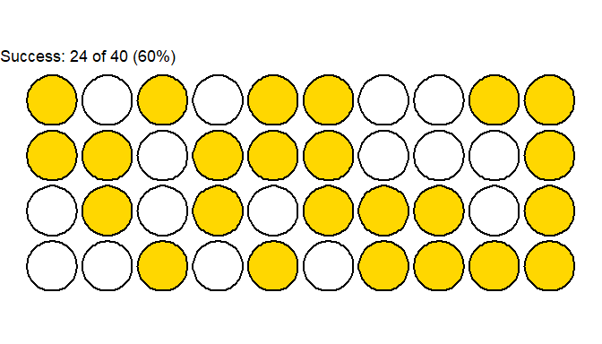

```r
set.seed(123)
flip_coin(times = 10, rounds = 4) %>%
  plot_coin()
```

#### Combine experiments

```r
set.seed(123)
flip_coin(times = 10, agg = TRUE) %>%
  flip_coin(times = 15, agg = TRUE)
```

```
#> # A tibble: 2 x 4
#>   experiment round times success
#>        <int> <int> <int>   <int>
#> 1          1     1    10       4
#> 2          2     1    15       8
```

#### Binomial Distribution

```r
binom_coin(times = 10)
```

```
#> # A tibble: 11 x 3
#>    success        p     pct
#>      <int>    <dbl>   <dbl>
#>  1       0 0.000977  0.0977
#>  2       1 0.00977   0.977
#>  3       2 0.0439    4.39
#>  4       3 0.117    11.7
#>  5       4 0.205    20.5
#>  6       5 0.246    24.6
#>  7       6 0.205    20.5
#>  8       7 0.117    11.7
#>  9       8 0.0439    4.39
#> 10       9 0.00977   0.977
#> 11      10 0.000977  0.0977
```

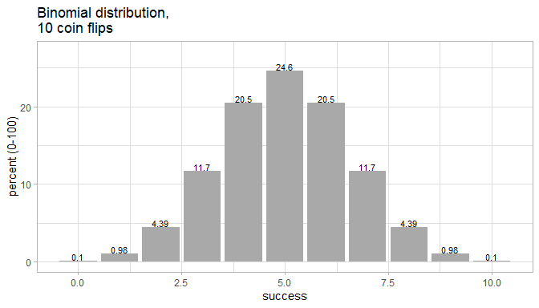

```r
binom_coin(times = 10) %>%
  plot_binom(title = "Binomial distribution,\n10 coin flips")
```

### Dice design

#### Default settings

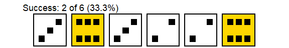

```r
set.seed(123)
roll_dice(times = 6) %>%
  plot_dice()
```

#### Change color

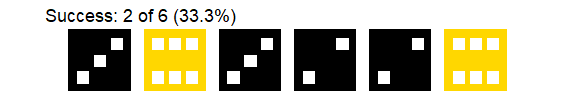

```r
set.seed(123)
roll_dice(times = 6) %>%
  plot_dice(fill = "black", line_color = "white", point_color = "white")
```

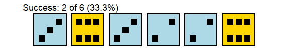

```r
set.seed(123)
roll_dice(times = 6) %>%
  plot_dice(fill = "lightblue", fill_success = "gold")
```

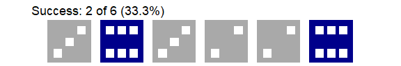

```r
set.seed(123)
roll_dice(times = 6) %>%
  plot_dice(fill = "darkgrey",
            fill_success = "darkblue",
            line_color = "white",
            point_color = "white")
```

#### Dice type

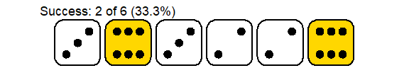

```r
set.seed(123)
roll_dice(times = 6) %>%
  plot_dice(detailed = TRUE)
```

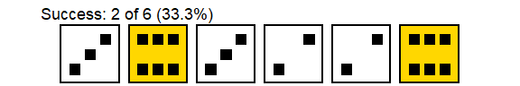

```r
set.seed(123)
roll_dice(times = 6) %>%
  plot_dice(detailed = FALSE)
```

#### Limits

plot_dice() is limited to 1 experiment with max. 10 times x 10 rounds.

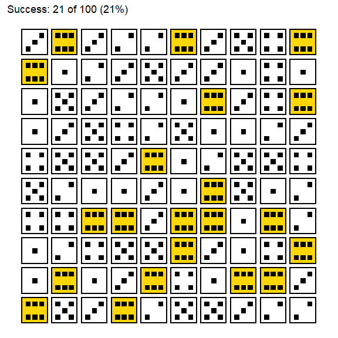

```r
set.seed(123)
roll_dice(times = 10, rounds = 10) %>%
  plot_dice(detailed = FALSE, fill_success = "gold")
```

#### Force

You can force a result using force_dice() and force_coin().

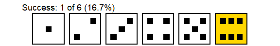

```r
force_dice(1:6) %>%
  plot_dice()
```

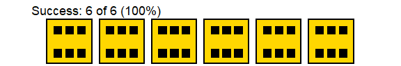

```r
force_dice(rep(6, times = 6)) %>%
  plot_dice()
```

We can combine two foreced dice rolling using the pipe operator and the parameter round.

```r
force_dice(rep(5, times = 3), round = 1) %>%
  force_dice(rep(6, times = 3), round = 2)
```

```
#> # A tibble: 6 x 5
#>   experiment round    nr result success
#>        <int> <int> <int>  <int> <lgl>
#> 1          1     1     1      5 FALSE
#> 2          1     1     2      5 FALSE
#> 3          1     1     3      5 FALSE
#> 4          1     2     1      6 TRUE
#> 5          1     2     2      6 TRUE
#> 6          1     2     3      6 TRUE
```

```r
set.seed(123)
force_dice(rep(6, times = 3)) %>%
  roll_dice(times = 3)
```

```
#> # A tibble: 6 x 5
#>   experiment round    nr result success
#>        <int> <int> <int>  <int> <lgl>
#> 1          1     1     1      6 TRUE
#> 2          1     1     2      6 TRUE
#> 3          1     1     3      6 TRUE
#> 4          2     1     1      3 FALSE
#> 5          2     1     2      6 TRUE
#> 6          2     1     3      3 FALSE
```

### Using Dice Formula

If you want to do more complex dice rolls, use `roll_dice_formula()`

```r
# roll 1 dice with 6 sides
roll_dice_formula(dice_formula = "1d6", seed = 123)
```

```
#> # A tibble: 1 x 7
#>   experiment dice_formula label round    nr result success
#>        <int> <chr>        <chr> <int> <int>  <dbl> <lgl>
#> 1          1 1d6          1d6       1     1      6 TRUE
```

```r
roll_dice_formula(
  dice_formula = "4d6", # 4 dice with 6 sides
  success = 15:24,      # success is defined as sum between 15 and 24
  seed = 123            # random seed to make it reproducible
)
```

```
#> # A tibble: 1 x 7
#>   experiment dice_formula label round    nr result success
#>        <int> <chr>        <chr> <int> <int>  <dbl> <lgl>
#> 1          1 4d6          4d6       1     1     18 TRUE
```

```r
# roll 4 dice with 6 sides
roll_dice_formula(
  dice_formula = "4d6", # 4 dice with 6 sides
  rounds = 10,          # repeat 10 times
  success = 15:24,      # success is defined as sum between 15 and 24
  seed = 123            # random seed to make it reproducible
)
```

```
#> # A tibble: 10 x 7
#>    experiment dice_formula label round    nr result success
#>         <int> <chr>        <chr> <int> <int>  <dbl> <lgl>
#>  1          1 4d6          4d6       1     1     13 FALSE
#>  2          1 4d6          4d6       2     1     10 FALSE
#>  3          1 4d6          4d6       3     1     14 FALSE
#>  4          1 4d6          4d6       4     1     16 TRUE
#>  5          1 4d6          4d6       5     1     12 FALSE
#>  6          1 4d6          4d6       6     1     14 FALSE
#>  7          1 4d6          4d6       7     1     15 TRUE
#>  8          1 4d6          4d6       8     1     12 FALSE
#>  9          1 4d6          4d6       9     1     15 TRUE
#> 10          1 4d6          4d6      10     1     10 FALSE
```

```r
roll_dice_formula(
  dice_formula = "4d6e3", # 4 dice with 6 sides, explode on a 3
  rounds = 5,             # repeat 5 times
  success = 15:24,        # success is defined as sum between 15 and 24
  seed = 123              # random seed to make it reproducible
)
```

```
#> # A tibble: 5 x 7
#>   experiment dice_formula label round    nr result success
#>        <int> <chr>        <chr> <int> <int>  <dbl> <lgl>
#> 1          1 4d6e3        4d6e3     1     1     18 TRUE
#> 2          1 4d6e3        4d6e3     2     1     15 TRUE
#> 3          1 4d6e3        4d6e3     3     1     15 TRUE
#> 4          1 4d6e3        4d6e3     4     1     13 FALSE
#> 5          1 4d6e3        4d6e3     5     1     12 FALSE
```

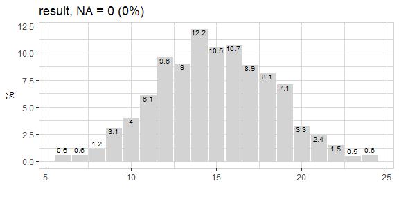

```r
roll_dice_formula(
  dice_formula = "4d6+1d10", # 4 dice with 6 sides + 1 dice with 10 sides
  rounds = 1000) %>%         # repeat 1000 times
  explore_bar(result, numeric = TRUE)  # visualise result
```

Other examples for dice_formula:

- `1d6` = roll one 6-sided dice
- `1d8` = roll one 8-sided dice
- `1d12` = roll one 12-sided dice
- `2d6` = roll two 6-sided dice
- `1d6e6` = roll one 6-sided dice, explode dice on a 6
- `3d6kh2` = roll three 6-sided dice, keep highest 2 rolls
- `3d6kl2` = roll three 6-sided dice, keep lowest 2 rolls
- `4d6kh3e6` = roll four 6-sided dice, keep highest 3 rolls, but explode on a 6
- `1d20+4` = roll one 20-sided dice, and add 4
- `1d4+1d6` = roll one 4-sided dice and one 6-sided dice, and sum the results